# 1. Introduction

In this project, I am going to explore the NYC AirBnb dataset to provide a GUI for potential AirBnB hosts or customers to easily unerstand where the listing is overpriced or not. This project can be used by AirBnB as well to find some hosts that are intentionally overpricing their properties.

## 1.1 Data source

This public dataset is part of Airbnb, and the original source can be found on this website: http://insideairbnb.com/ This dataset describes the listing activity and metrics in NYC, NY for 2019.

## 1.2 Data definitions

id: listing ID  
name: name of the listing  
host_id: host ID  
host_name: name of the host  
neighbourhood_group: location  
neighbourhood: area  
latitude: latitude coordinates  
longitude: longitude coordinates  
room_type: listing space type  
price: price in dollars  
minimum_nights: amount of nights minimum  
number_of_reviews: number of reviews  
last_review: latest review  
reviews_per_month: number of reviews per month  
calculated_host_listings_count : amount of listing per host  
availability_365: number of days when listing is available for booking

# 2. EDA

Let's explore our data! First up, data loading

## 2.1 Data loading and understanding

Let's load in some helpful packages and dataset.

```python
# loading helpful packages

import numpy as np # linear algebra
import pandas as pd # data processing, CSV file I/O (e.g. pd.read_csv)

#loading dataset
df=pd.read_csv("AB_NYC_2019.csv")
```

Let's quickly look at the data.

```python
df.head()
```

|  | id | name | host_id | host_name | neighbourhood_group | neighbourhood | latitude | longitude | room_type | price | minimum_nights | number_of_reviews | last_review | reviews_per_month | calculated_host_listings_count | availability_365 |
| --- | --- | --- | --- | --- | --- | --- | --- | --- | --- | --- | --- | --- | --- | --- | --- | --- |
| 0 | 2539 | Clean & quiet apt home by the park | 2787 | John | Brooklyn | Kensington | 40.64749 | -73.97237 | Private room | 149 | 1 | 9 | 2018-10-19 | 0.21 | 6 | 365 |
| 1 | 2595 | Skylit Midtown Castle | 2845 | Jennifer | Manhattan | Midtown | 40.75362 | -73.98377 | Entire home/apt | 225 | 1 | 45 | 2019-05-21 | 0.38 | 2 | 355 |
| 2 | 3647 | THE VILLAGE OF HARLEM....NEW YORK ! | 4632 | Elisabeth | Manhattan | Harlem | 40.80902 | -73.94190 | Private room | 150 | 3 | 0 | NaN | NaN | 1 | 365 |
| 3 | 3831 | Cozy Entire Floor of Brownstone | 4869 | LisaRoxanne | Brooklyn | Clinton Hill | 40.68514 | -73.95976 | Entire home/apt | 89 | 1 | 270 | 2019-07-05 | 4.64 | 1 | 194 |
| 4 | 5022 | Entire Apt: Spacious Studio/Loft by central park | 7192 | Laura | Manhattan | East Harlem | 40.79851 | -73.94399 | Entire home/apt | 80 | 10 | 9 | 2018-11-19 | 0.10 | 1 | 0 |

Ah I can see the NaN values in some columns already. Let's take a look at the dataframe info.

```python
df.info(verbose=True)
```

```
<class 'pandas.core.frame.DataFrame'>
RangeIndex: 48895 entries, 0 to 48894
Data columns (total 16 columns):
id                                48895 non-null int64
name                              48879 non-null object
host_id                           48895 non-null int64
host_name                         48874 non-null object
neighbourhood_group               48895 non-null object
neighbourhood                     48895 non-null object
latitude                          48895 non-null float64
longitude                         48895 non-null float64
room_type                         48895 non-null object
price                             48895 non-null int64
minimum_nights                    48895 non-null int64
number_of_reviews                 48895 non-null int64
last_review                       38843 non-null object
reviews_per_month                 38843 non-null float64
calculated_host_listings_count    48895 non-null int64
availability_365                  48895 non-null int64
dtypes: float64(3), int64(7), object(6)
memory usage: 6.0+ MB
```

From this we can see that we have 48,895 entries and 16 columns but some columns (name, host_name, etc) have less non-null values which means there are NaN values.

How many of these are unique values? Although the describe method showed that info, let's generate a plot to show the percentage of unique records for each column ( # of unique vlues in 1 column / # of total records in 1 column *100)

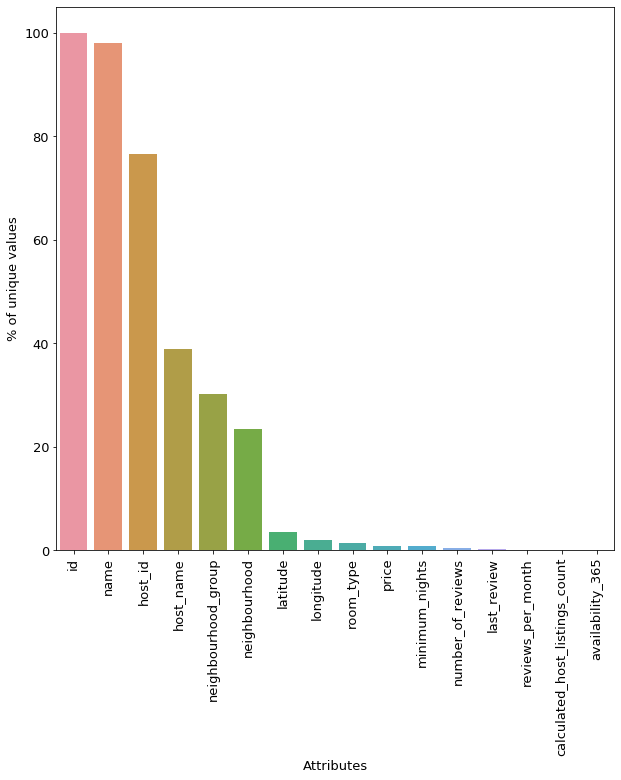

```python
#importing seaborn
import seaborn as sns
import matplotlib.pyplot as plt

#setting font style for the entire plots in this notebook
font = {'weight' : 'normal',
        'size'   : 13}
plt.rc('font', **font)

plt.figure(figsize=(10,10))
g=sns.barplot(x=df.columns.tolist(), y=100*(df.nunique().sort_values(ascending=False).reset_index()[0]/len(df)))
g.set_xticklabels(g.get_xticklabels(), rotation=90)
g.set_xlabel("Attributes")
g.set_ylabel("% of unique values")
```

It is interesting to note that the percentage of the unique "names" is not 100%, which indicates that some of the listings are duplicate. The same goes for host_name which means a lot of listings were uploaded by the same host.

Let's generate descriptive statistics for our dataframe.

```python
df.describe(include='all').transpose()
```

|  | count | unique | top | freq | mean | std | min | 25% | 50% | 75% | max |
| --- | --- | --- | --- | --- | --- | --- | --- | --- | --- | --- | --- |
| id | 48895 | NaN | NaN | NaN | 1.90171e+07 | 1.09831e+07 | 2539 | 9.47194e+06 | 1.96773e+07 | 2.91522e+07 | 3.64872e+07 |
| name | 48879 | 47905 | Hillside Hotel | 18 | NaN | NaN | NaN | NaN | NaN | NaN | NaN |
| host_id | 48895 | NaN | NaN | NaN | 6.762e+07 | 7.8611e+07 | 2438 | 7.82203e+06 | 3.07938e+07 | 1.07434e+08 | 2.74321e+08 |
| host_name | 48874 | 11452 | Michael | 417 | NaN | NaN | NaN | NaN | NaN | NaN | NaN |
| neighbourhood_group | 48895 | 5 | Manhattan | 21661 | NaN | NaN | NaN | NaN | NaN | NaN | NaN |
| neighbourhood | 48895 | 221 | Williamsburg | 3920 | NaN | NaN | NaN | NaN | NaN | NaN | NaN |
| latitude | 48895 | NaN | NaN | NaN | 40.7289 | 0.0545301 | 40.4998 | 40.6901 | 40.7231 | 40.7631 | 40.9131 |
| longitude | 48895 | NaN | NaN | NaN | -73.9522 | 0.0461567 | -74.2444 | -73.9831 | -73.9557 | -73.9363 | -73.713 |
| room_type | 48895 | 3 | Entire home/apt | 25409 | NaN | NaN | NaN | NaN | NaN | NaN | NaN |
| price | 48895 | NaN | NaN | NaN | 152.721 | 240.154 | 0 | 69 | 106 | 175 | 10000 |
| minimum_nights | 48895 | NaN | NaN | NaN | 7.02996 | 20.5105 | 1 | 1 | 3 | 5 | 1250 |
| number_of_reviews | 48895 | NaN | NaN | NaN | 23.2745 | 44.5506 | 0 | 1 | 5 | 24 | 629 |
| last_review | 38843 | 1764 | 2019-06-23 | 1413 | NaN | NaN | NaN | NaN | NaN | NaN | NaN |
| reviews_per_month | 38843 | NaN | NaN | NaN | 1.37322 | 1.68044 | 0.01 | 0.19 | 0.72 | 2.02 | 58.5 |
| calculated_host_listings_count | 48895 | NaN | NaN | NaN | 7.14398 | 32.9525 | 1 | 1 | 1 | 2 | 327 |
| availability_365 | 48895 | NaN | NaN | NaN | 112.781 | 131.622 | 0 | 0 | 45 | 227 | 365 |

Let's foucs on the price information as that is going to be our target. I did not know that there are some $0 AirBnB (look at the min of price column). Also there is a \\$10,000 AirBnB! Something to note is the mean of the price, \$152.

## 2.2 Data visualization : part 1

I will first take a look at the pairplot of the dataframe. I am going to exclude id and host_id from the dataframe though as they are arbitraily assigned to each listing.

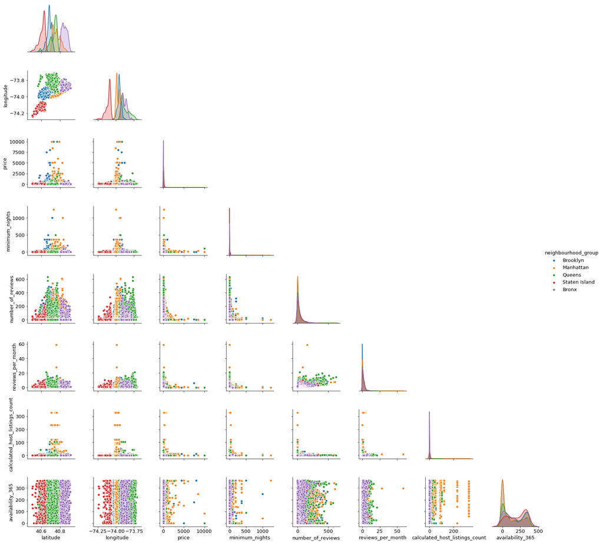

```python
#excluding id and host_id.
df=df.drop(['id','host_id'],axis=1)
#creating pairplots. Dropping any NaN values for seaborn pairplots
g = sns.pairplot(df.dropna(),hue='neighbourhood_group',height=2.5,corner=True)
```

It is hard to see to be honest, but if we focus on the price variable, we can see it is highly skewed. Let's take a closer look at it.

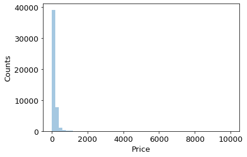

```python
#looking at price distribution
g=sns.distplot(df['price'],kde = False)
g.set_xlabel("Price")
g.set_ylabel("Counts")
```

We can see that our data is significantly right-skewed. Let's correct this by applying a log scale to price.

One thing we need to note though is that since there are some \$0 price tags in our dataframe, which will cause a problem because log(0) cannot be defined.

To resolve this issue while preserving the dataframe's feature as much as possible, we can add a very small constant to the price column. I will add \$1 to the price in the dataframe and then apply logarthmic function. This actually does not modify the nature of price dataset too much as log(1) = 0.

Let's replot the histogram after this logarithmic transfomration.

```python
#adding a small constant to the price column to prevent log(0) issue and assign a new column
df['log_price'] = np.log(df['price']+1)
```

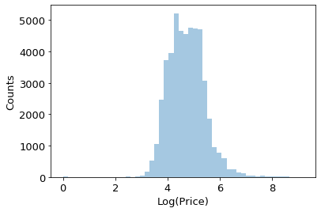

```python
g=sns.distplot(df['log_price'],kde = False)
g.set_xlabel("Log(Price)")
g.set_ylabel("Counts")
```

Now it looks much more like our typical normal distribution. :)

However, we have to be careful with logarihmic transformation. Leigh Metcalf et al. said in their "Introduction to data analysis" book published in 2016 that "a process that de-emphasizes them (outliers)is not useful" if we want to analyze the outliers and "if the distance between each variable is important, then taking the log of the variable skews the distance".

These do not apply to our case so let's use log_price for our data analysis. I will create a separate dataframe where log_price replaced price.

```python
#making a separate dataframe that contains log_price instead of price
df_log=df.drop("price",axis=1)
```

I also looked at the effect of reviews (number_of_reviews and reviews_per_month) on the log_price.

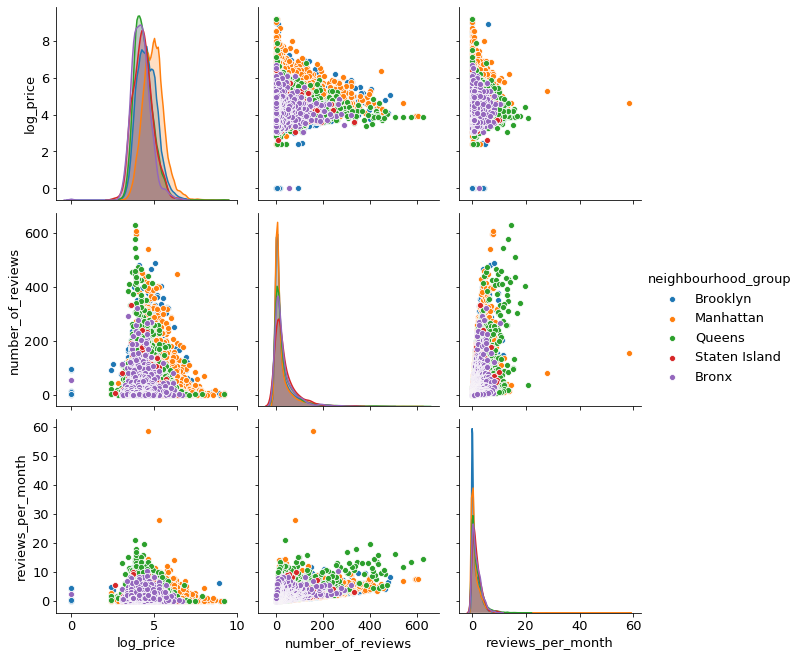

```python
g = sns.pairplot(df.dropna(), height=3,
                 vars=["log_price", "number_of_reviews","reviews_per_month"],hue='neighbourhood_group')
```

We can see from the plots above that generally as we get more reviews the prices tended to go down in all neighbourhoods. Also the distribution is highly skewed due to outliers so we better use median not mean when filling in missing values.

Let's take a look at the correlation plot to see how numerical features are related to our target, log_price.

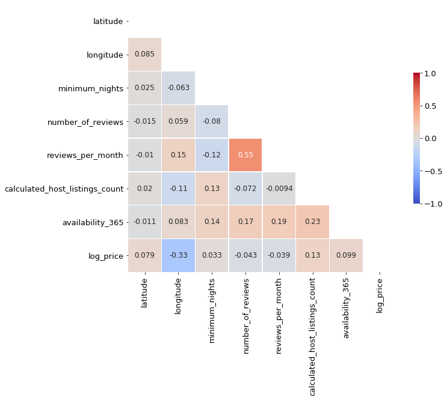

```python
#getting the correlation matrix
corr_matrix=df_log.corr()
#creating a mask to block the upper triangle of coorelation matrix
mask = np.zeros_like(corr_matrix, dtype=np.bool)
mask[np.triu_indices_from(mask)]= True

#plotting correlation
f, ax = plt.subplots(figsize=(10, 10))
heatmap = sns.heatmap(corr_matrix,
                      mask = mask,
                      square = True,
                      linewidths = .5,
                      cmap = 'coolwarm',
                      cbar_kws = {'shrink': .4,
                                'ticks' : [-1, -.5, 0, 0.5, 1]},
                      vmin = -1,
                      vmax = 1,
                      annot = True,
                      annot_kws = {'size': 12})

#add the column names as labels
ax.set_yticklabels(corr_matrix.columns, rotation = 0)
ax.set_xticklabels(corr_matrix.columns)
sns.set_style({'xtick.bottom': True}, {'ytick.left': True})
```

If we focus on the log_price row in the correlation map (last row), we can see that longitude has strong negative correlation. Let's take a look at the Seaborn regression plot between the longigute and log_price.

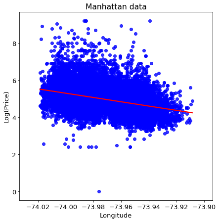

```python
#Manhattan only dataframe creation
df_manhattan=df[df['neighbourhood_group']=='Manhattan']
plt.figure(figsize=(7,7))
sns.regplot(x='longitude',y='log_price',data=df_manhattan, scatter_kws={"color": "blue"}, line_kws={"color": "red"})
plt.title('Manhattan data')
plt.xlabel('Longitude')
plt.ylabel('Log(Price)')
```

Ok. I would also like to see how long the AirBnB listings typically had lasted

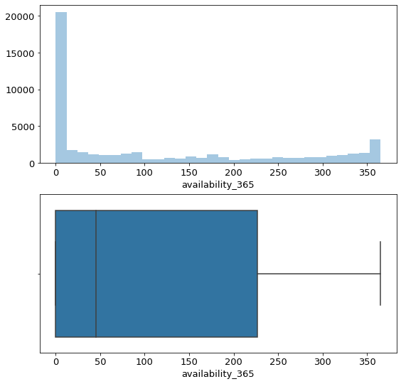

```python
fig,ax=plt.subplots(2,figsize=(9,9))
#Creating a histogram for availablity
sns.distplot(df["availability_365"], kde=False,ax=ax[0])

#Creating a box plot for availablity
sns.boxplot("availability_365",data=df,ax=ax[1])
```

From this, we can see that the listings stayed available for booking for ~50 days (median), which means most of them did not remain available that long.

Finally, I would like to see what typical words the hosts used when listing. As we saw above the listing names were something descriptive like "Clean&quiet apt home by the park". There might be something interesting to note.

```python
#first making the df['name'] series lower-case. Then, apply 'str.split' to split each sentence in each row by whitespace.
#After that drop any NaN values in the series and then covert the series to a list.

split_name_list=df['name'].str.lower().str.split().dropna().tolist()
#flatten the nested list
flatten_name_list = [val for sublist in split_name_list for val in sublist]
```

Ok. Now I want to remove some "stopwords" such as articles (a, the) or connecting words (and, but). The nltk library already has common stopwords defined.

```python
#importing nltk library to use stopwords
import nltk

#need to first download the stopwords using the follwoing link: nltk.download('stopwords')
#nltk.download('stopwords')

from nltk.corpus import stopwords
stop_words = set(stopwords.words('english'))
```

Ok now let's filter out these stop words from our flatten_name_list. I will use list comprehension again because we eventually need a list to feed into Counter class in Collection module.

```python
filtered_sentence = [w for w in flatten_name_list if not w in stop_words]
```

Ok. Let's use Counter to count the most 10 common words.

```
{'room': 9389, 'bedroom': 7231, 'private': 6985, 'apartment': 6113, 'cozy': 4634, 'studio': 3772, 'brooklyn': 3629, 'apt': 3571, 'spacious': 3387, '1': 3357}
```

```
<BarContainer object of 10 artists>
```

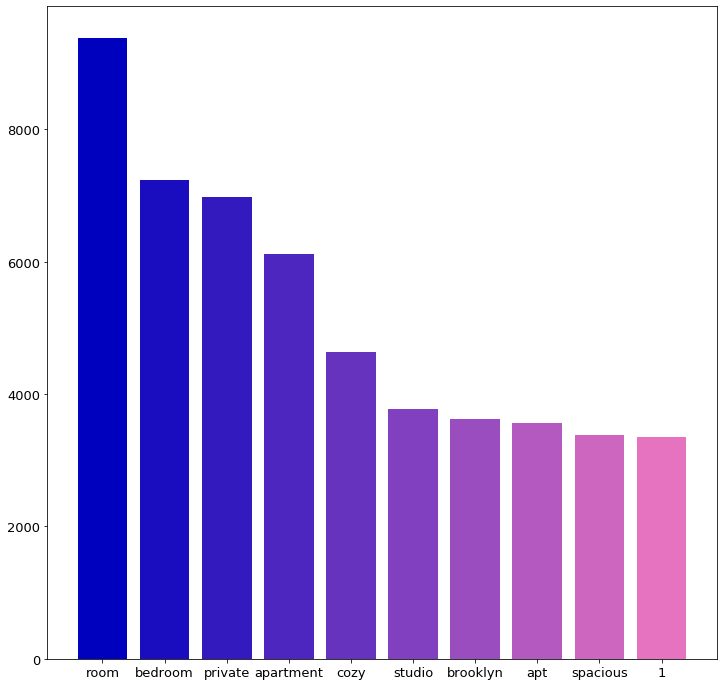

```python
#importing counter
from collections import Counter
#counting the occurences of filtered_sentence words
c = Counter(filtered_sentence)
#getting the top 10 counted words
most_common_word=c.most_common(10)
#printing dictionary of the top 10 words
print(dict(most_common_word))

plt.figure(figsize=(12,12))

#generating random colors (Gradient) for bars
my_colors = [(x/10.0, x/20.0, 0.75) for x in range(len(dict(most_common_word)))]

#plotting
plt.bar(dict(most_common_word).keys(), dict(most_common_word).values(),color=my_colors)
```

Not surprisingly, people used 'room' the most in their listings. Something like private or cozy are also noteworthy. Alright, let's move on to fetaure engineering in preparation of our price prediction.

## 2.4 Data visualization - Part 2

Ok. Now let's visually plot our target variable, log_price. It seems we have latitude and longitude data, meaning we can generate a 'map' for the prices. I will use a scatter plot to map the prices overlay the NYC map as well.For the overlaying map, I downloaded the shapefiles from https://data.cityofnewyork.us/City-Government/Borough-Boundaries/tqmj-j8zmand uploaded them to this direcotry. We will use Geopandas for plotting the shapefile.

```python
# import Geopandas libraries
import geopandas as gpd

# import street map
street_map = gpd.read_file('geo_export_1a40feae-9f19-49a0-91fa-3ba4f4254e79.shp')
```

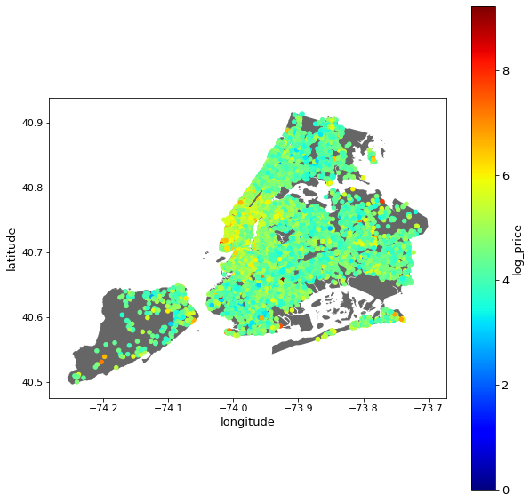

```python
# create figure and axes, assign to subplot
fig, ax = plt.subplots(1,1,figsize=(10,10))

#plotting the price as a function of longitude and latitude
ax=df.plot(x='longitude',y='latitude', c='log_price',kind='scatter',cmap='jet',ax=ax,zorder=5,fontsize=11)
plt.xlabel('longitude')
plt.ylabel('latitude')
# add .shp mapfile to axes
street_map.plot(ax=ax,alpha=0.6,color='black',legend=True)
plt.show()
```

Now we can see that the most of expensive ones are in the Manhattan island, which is not very surprising.

# 3. Data pre-processing

Let's take a look at our dataframe one more time before we work on data pre-processing

```python
df_log.head()
```

|  | name | host_name | neighbourhood_group | neighbourhood | latitude | longitude | room_type | minimum_nights | number_of_reviews | last_review | reviews_per_month | calculated_host_listings_count | availability_365 | log_price |
| --- | --- | --- | --- | --- | --- | --- | --- | --- | --- | --- | --- | --- | --- | --- |
| 0 | Clean & quiet apt home by the park | John | Brooklyn | Kensington | 40.64749 | -73.97237 | Private room | 1 | 9 | 2018-10-19 | 0.21 | 6 | 365 | 5.010635 |
| 1 | Skylit Midtown Castle | Jennifer | Manhattan | Midtown | 40.75362 | -73.98377 | Entire home/apt | 1 | 45 | 2019-05-21 | 0.38 | 2 | 355 | 5.420535 |
| 2 | THE VILLAGE OF HARLEM....NEW YORK ! | Elisabeth | Manhattan | Harlem | 40.80902 | -73.94190 | Private room | 3 | 0 | NaN | NaN | 1 | 365 | 5.017280 |
| 3 | Cozy Entire Floor of Brownstone | LisaRoxanne | Brooklyn | Clinton Hill | 40.68514 | -73.95976 | Entire home/apt | 1 | 270 | 2019-07-05 | 4.64 | 1 | 194 | 4.499810 |
| 4 | Entire Apt: Spacious Studio/Loft by central park | Laura | Manhattan | East Harlem | 40.79851 | -73.94399 | Entire home/apt | 10 | 9 | 2018-11-19 | 0.10 | 1 | 0 | 4.394449 |

Any features to drop? What about something like names (AirBnB listing names)? or the host names? First of all, listing_names should not signicantly affect prices as many people will use attractive words or descriptions. The host_name also should not matter. Let's check on my hypothesis by plotting price as a fucntion of these attributes from the orignal dataframe, df.

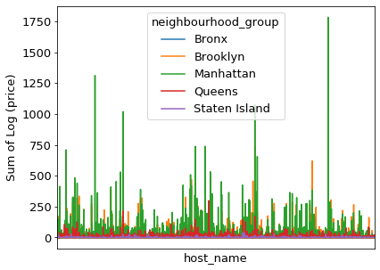

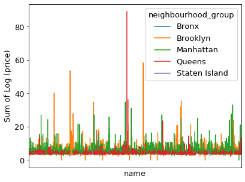

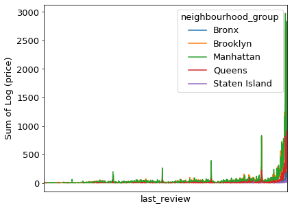

```python
#gropuing by neighbourhood_group and host_name to get the sum of the log_price for each group and unstack to do plotting
#filling in 0 for missing values. Not showing xtick labels intentionally

##plotting sum of log price vs host_name
plt.figure(1,figsize=(14,11))
plt.subplot(2,2,1)
df_log.groupby(['neighbourhood_group', 'host_name'])['log_price'].sum().unstack('neighbourhood_group', fill_value=0).plot(ax=plt.gca())
plt.xticks([])
plt.ylabel("Sum of Log (price)")
##plotting sum of log price vs name
plt.figure(2,figsize=(14,11))
plt.subplot(2,2,2)
df_log.groupby(['neighbourhood_group', 'name'])['log_price'].sum().unstack('neighbourhood_group').plot(ax=plt.gca())
plt.xticks([])
plt.ylabel("Sum of Log (price)")

##plotting sum of log price vs last_review
plt.figure(3,figsize=(14,11))
plt.subplot(2,2,3)
df_log.groupby(['neighbourhood_group', 'last_review'])['log_price'].sum().unstack('neighbourhood_group').plot(ax=plt.gca())
plt.xticks([])
plt.ylabel("Sum of Log (price)")
```

We can see that the names and host names do not really have a strong effect on prices. Let's drop these attributes altogether for easier machine learning model development.

Even though the last_review shows that we have a trend, this is misleading because most of the listings might have been populated recently. Logically the date when the last review was created should have a minimal effect than the number of reviews so I will drop it for this analysis.

```python
df_log=df_log.drop(["last_review","host_name","name"],axis=1)
```

Let's take a look at our dataframe to see our work until now.

```python
df_log.head()
```

|  | neighbourhood_group | neighbourhood | latitude | longitude | room_type | minimum_nights | number_of_reviews | reviews_per_month | calculated_host_listings_count | availability_365 | log_price |
| --- | --- | --- | --- | --- | --- | --- | --- | --- | --- | --- | --- |
| 0 | Brooklyn | Kensington | 40.64749 | -73.97237 | Private room | 1 | 9 | 0.21 | 6 | 365 | 5.010635 |
| 1 | Manhattan | Midtown | 40.75362 | -73.98377 | Entire home/apt | 1 | 45 | 0.38 | 2 | 355 | 5.420535 |
| 2 | Manhattan | Harlem | 40.80902 | -73.94190 | Private room | 3 | 0 | NaN | 1 | 365 | 5.017280 |
| 3 | Brooklyn | Clinton Hill | 40.68514 | -73.95976 | Entire home/apt | 1 | 270 | 4.64 | 1 | 194 | 4.499810 |
| 4 | Manhattan | East Harlem | 40.79851 | -73.94399 | Entire home/apt | 10 | 9 | 0.10 | 1 | 0 | 4.394449 |

```python
#separating labels and predictors
X=df_log.drop('log_price',axis=1)
y=df_log['log_price'].values

#splitting train (75%) and test set (25%)
from sklearn.model_selection import train_test_split
X_train, X_test, y_train, y_test = train_test_split(X, y, test_size=0.25, random_state=42)
```

```python
X_train.head()
```

|  | neighbourhood_group | neighbourhood | latitude | longitude | room_type | minimum_nights | number_of_reviews | reviews_per_month | calculated_host_listings_count | availability_365 |
| --- | --- | --- | --- | --- | --- | --- | --- | --- | --- | --- |
| 542 | Brooklyn | Bedford-Stuyvesant | 40.68497 | -73.95592 | Entire home/apt | 3 | 207 | 2.18 | 1 | 304 |
| 18954 | Queens | Edgemere | 40.59324 | -73.77288 | Private room | 30 | 1 | 0.04 | 43 | 354 |
| 3852 | Brooklyn | Crown Heights | 40.67026 | -73.92587 | Entire home/apt | 2 | 17 | 0.39 | 1 | 0 |
| 34822 | Manhattan | Washington Heights | 40.85268 | -73.92716 | Entire home/apt | 1 | 42 | 4.00 | 1 | 2 |
| 41630 | Bronx | Kingsbridge | 40.88474 | -73.90321 | Private room | 30 | 0 | NaN | 37 | 0 |

Now let's separate numerical and categorical attributes to go through different transormation pipelines.

```python
#Selecting numerical dataframe in train set
X_train_num=X_train.select_dtypes(include=np.number)

#Selecting categorical dataframe in train set
X_train_cat=X_train.select_dtypes(exclude=['number'])
```

```python
X_train_num.head()
```

|  | latitude | longitude | minimum_nights | number_of_reviews | reviews_per_month | calculated_host_listings_count | availability_365 |
| --- | --- | --- | --- | --- | --- | --- | --- |
| 542 | 40.68497 | -73.95592 | 3 | 207 | 2.18 | 1 | 304 |
| 18954 | 40.59324 | -73.77288 | 30 | 1 | 0.04 | 43 | 354 |
| 3852 | 40.67026 | -73.92587 | 2 | 17 | 0.39 | 1 | 0 |
| 34822 | 40.85268 | -73.92716 | 1 | 42 | 4.00 | 1 | 2 |
| 41630 | 40.88474 | -73.90321 | 30 | 0 | NaN | 37 | 0 |

```python
X_train_cat.head()
```

|  | neighbourhood_group | neighbourhood | room_type |
| --- | --- | --- | --- |
| 542 | Brooklyn | Bedford-Stuyvesant | Entire home/apt |
| 18954 | Queens | Edgemere | Private room |
| 3852 | Brooklyn | Crown Heights | Entire home/apt |
| 34822 | Manhattan | Washington Heights | Entire home/apt |
| 41630 | Bronx | Kingsbridge | Private room |

The issue with OneHotEncoding here is though that it will create a sparse matrix as it needs to create a 'hot' element for each of 221 unique neighbourhoods. While a sparse matrix is ok to have, it will make tree-based machine modeling worse as only a small fraction of the data is likely to belong to any given level, so the one-hot encoded columns will be mostly zeros and tree-based algorithms typically can ignore the information in favor of other columns. Thus, I will drop the neighbourhood feature. Plus, the information about neighbourhood is somewhat contained in neighbourhood_group, longitude and latitude in our dataset.

```python
#dropping 'neighbourhood' feature from trainset and categorical attribute dataframe
X_train=X_train.drop('neighbourhood',axis=1)
X_train_cat=X_train_cat.drop('neighbourhood',axis=1)

#do the same for the test set
X_test=X_test.drop('neighbourhood',axis=1)
```

```python
#importing necessary classes from sklearn
from sklearn.impute import SimpleImputer
#importing ColumnTransformer and OneHotEncoder
from sklearn.compose import ColumnTransformer
from sklearn.preprocessing import OneHotEncoder

#separating numerical and categorical attributes in the train set
num_attribs = list (X_train_num)
cat_attribs = list (X_train_cat)

#creating a full pipeline: numerical + categorical
full_pipeline = ColumnTransformer([("num",SimpleImputer(strategy='median'),num_attribs),("cat",OneHotEncoder(handle_unknown='ignore'),cat_attribs)])

#fit and transform the train set using the full pipeline
X_train_prepd = full_pipeline.fit_transform(X_train)
```

```python
X_train_prepd
```

```
array([[ 40.68497, -73.95592,   3.     , ...,   1.     ,   0.     ,
          0.     ],
       [ 40.59324, -73.77288,  30.     , ...,   0.     ,   1.     ,
          0.     ],
       [ 40.67026, -73.92587,   2.     , ...,   1.     ,   0.     ,
          0.     ],
       ...,
       [ 40.78318, -73.97372,  30.     , ...,   1.     ,   0.     ,
          0.     ],
       [ 40.77508, -73.9799 ,   2.     , ...,   1.     ,   0.     ,
          0.     ],
       [ 40.74657, -73.94555,   5.     , ...,   1.     ,   0.     ,
          0.     ]])
```

Ok now we are good to go to train our machine learning models.

# 4. Modeling : Random forest regression

## 4.1 Training the model : effect of target variable skewedness

Let's try RandomForestRegressor for both price and log_price cases. I chose hyperparameters myself to be simple.

```python
from sklearn.metrics import mean_squared_error

#converting the log_price target labels back to price
y_train_exp=np.expm1(y_train)

#importing random forest regressor
from sklearn.ensemble import RandomForestRegressor

#choose 50 number of trees
forest_reg=RandomForestRegressor(n_estimators = 50, random_state = 42)

#fitting the training set: target variable is price
forest_reg.fit(X_train_prepd,y_train_exp)

#making predictions
forest_predictions_exp=forest_reg.predict(X_train_prepd)

#getting MSE and RMSE values
forest_mse_exp=mean_squared_error(y_train_exp,forest_predictions_exp)
forest_rmse_exp=np.sqrt(forest_mse_exp)

print("Mean squared error: %.3f" % forest_mse_exp)
print("Root mean squared error: %.3f" % forest_rmse_exp)
```

```
Mean squared error: 7970.092
Root mean squared error: 89.275
```

Moving on to log_price case.

```python
#importing random forest regressor
from sklearn.ensemble import RandomForestRegressor

#choose 50 number of trees
forest_reg=RandomForestRegressor(n_estimators = 50, random_state = 42)

#fitting the training set : arget variable is log_price
forest_reg.fit(X_train_prepd,y_train)

#making predictions
forest_predictions=forest_reg.predict(X_train_prepd)

#getting MSE and RMSE values
forest_mse=mean_squared_error(y_train,forest_predictions)
forest_rmse=np.sqrt(forest_mse)

print("Mean squared error: %.3f" % forest_mse)
print("Root mean squared error: %.3f" % forest_rmse)
```

```
Mean squared error: 0.029
Root mean squared error: 0.171
```

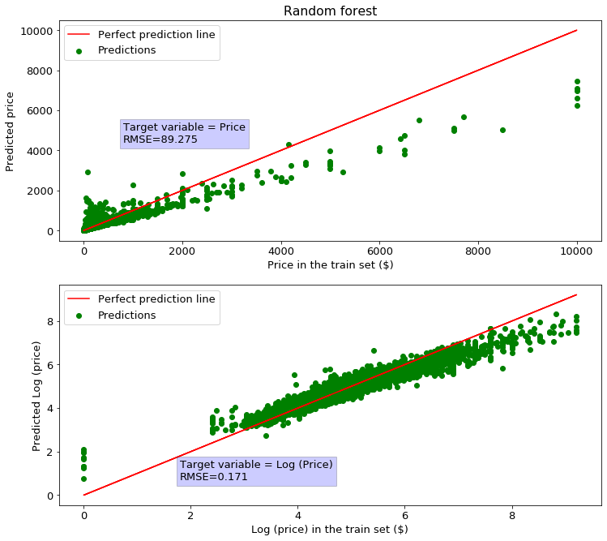

```python
plt.figure(figsize=(12, 11))
#plotting for the price case
plt.subplot(211)
plt.title("Random forest")
plt.scatter(y_train_exp,forest_predictions_exp, label='Predictions',color='g')
plt.plot(y_train_exp,y_train_exp,'r',label='Perfect prediction line')

#labeling
plt.xlabel("Price in the train set ($)")
plt.ylabel("Predicted price")
plt.text(800, 4400, 'Target variable = Price'+'\n'+'RMSE=%.3f' % forest_rmse_exp, bbox=dict(facecolor='blue', alpha=0.2))
plt.legend()

#plotting for the log_price case
plt.subplot(212)
plt.scatter(y_train,forest_predictions, label='Predictions',color='g')
plt.plot(y_train,y_train,'r',label='Perfect prediction line')

#labeling
plt.xlabel("Log (price) in the train set ($)")
plt.ylabel("Predicted Log (price)")
plt.text(1.8, 0.7, 'Target variable = Log (Price)'+'\n'+'RMSE=%.3f' % forest_rmse, bbox=dict(facecolor='blue', alpha=0.2))

plt.legend()
```

This again shows how the random forest model suffered with the presence of ourliers to some extent. For the log_price case, the predictions are great for the middle prices but started getting worse for the high price data. This might have happened because we had mixed attributes and tree-based models generally prefer continuous variables over categorical variables.

Let's get the cross validation score on the random forest model for the log_price case only to see if we are overfitting again. This time cross validation happeend across 5 folds to reduce run time.

```python
from sklearn.model_selection import cross_val_score
#performing 5fold validation
scores=cross_val_score(forest_reg, X_train_prepd, y_train, scoring = "neg_mean_squared_error",cv=5)

# skleanr's cross validation expect a utility function, so the greater the better.
# That is why putting a negative sign
forest_rmse_scores=np.sqrt(-scores)
print("Scores:", forest_rmse_scores)
print("Mean: %.3f" % forest_rmse_scores.mean())
print("STD: %.3f" % forest_rmse_scores.std())
```

```
Scores: [0.44061838 0.4601939  0.43728627 0.45658018 0.46594573]
Mean: 0.452
STD: 0.011
```

The training set RMSE is smaller than the validation set RMSE so we can see we are overfitting.

We can try keep tuning the hyperparameters to make this better. Let's try grid search.

```python
#turning grid_search on and off
grid_search="off"

if grid_search=="on":
    from sklearn.model_selection import GridSearchCV
#choosing parameters to test
    forest_reg_gs=RandomForestRegressor()
    param_grid=[{'n_estimators':[20,30,40,50,60],'max_features':[3,6,9,12]},
                {'bootstrap':[False],'n_estimators':[20,30,40,50],'max_features':[3,6,9]}]

    grid_search = GridSearchCV(forest_reg_gs,param_grid,cv=5,scoring='neg_mean_squared_error',return_train_score=True)
    grid_search.fit(X_train_prepd,y_train)
    print(grid_search.best_estimator_)
else:
    pass
```

The result of this grid_search was as follows.

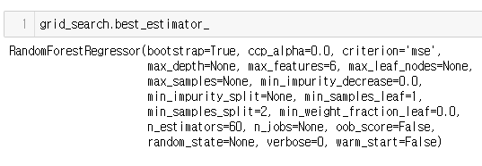

```python
from IPython.display import Image
Image(filename = "rf_best.PNG", width=600, height=600)
```

I re-fitted my training set with these new "Best" hyperparameters for both cases again and got the following plots.

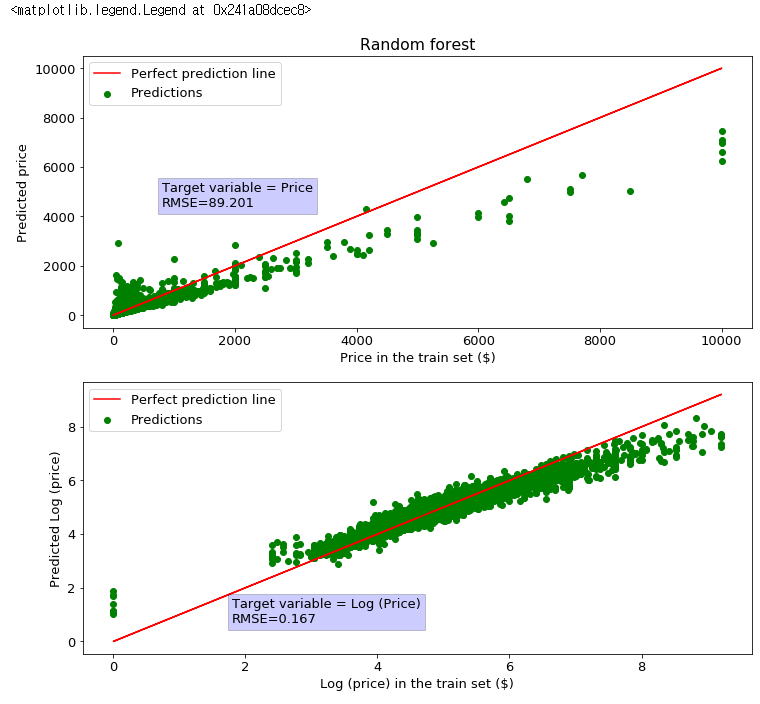

```python
#diplaying a screenshot for pre-run RF modeling with the best parameters
from IPython.display import Image
Image(filename = "rf_grid.PNG", width=600, height=600)
```

Not a huge improvement in terms of RMSE. I will stick with the original hyper parameters for simplicity.

Now I want to take a look at how each feature affected random forest modeling, a.k.a feature importances.

```python
#to show the pair of tuples in feature_importances
for feature in zip(X_train.columns, forest_reg.feature_importances_):
    print(feature)

feats = {} # a dict to hold feature_name: feature_importance
for feature, importance in zip(X_train.columns, forest_reg.feature_importances_):
    feats[feature] = importance #add the name/value pair
```

```
('neighbourhood_group', 0.15175604674430992)
('latitude', 0.15906332650503116)
('longitude', 0.05498848100761865)
('room_type', 0.05022536465375785)
('minimum_nights', 0.054011156685955033)
('number_of_reviews', 0.031688650290917386)
('reviews_per_month', 0.08072367278817162)
('calculated_host_listings_count', 0.0004488036672709168)
('availability_365', 0.0009944787121788365)
```

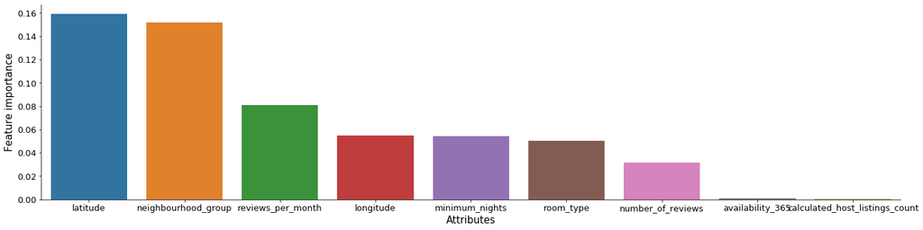

```python
#creating a dataframe from 'feats' dict. Setting dict keys as an index and renaming name of the importance value column
importances = pd.DataFrame.from_dict(feats, orient='index').rename(columns={0: 'Feature importance'})

#sort the importance value by an descending order and create a bar plot
importances=importances.sort_values(by='Feature importance',ascending=False).reset_index()
sns.catplot(kind='bar',x='index',y='Feature importance',data=importances,height=5, aspect=3.9)
plt.xlabel('Attributes', fontsize=15)
plt.ylabel('Feature importance', fontsize=15)
```

## 4.2 Evaluate on the test set

Let's transform the test set. One thing to be careful is that we should NOT fit_transform the test set because the whole point of ML is to train the model so that it can make good predictions on test set. We don't want the model to cheat by optimizing the model to the test set.

```python
#Do NOT fit the test data. Only transform using the pipeline
X_test_prepd=full_pipeline.transform(X_test)
```

```python
#Making predictions using random forest model trained above
final_predictions = forest_reg.predict(X_test_prepd)

#getting mse and rmse values
final_mse = mean_squared_error(y_test,final_predictions)
final_rmse = np.sqrt(final_mse)

print("Mean squared error: %.3f" % final_mse)
print("Root mean squared error: %.3f" % final_rmse)
```

```
Mean squared error: 0.191
Root mean squared error: 0.437
```

As we expected because we were overfitting our training dataset with the RandomForest model, the predictions on the test dataset are not great and the rmse got much larger. Let's compare the predictions and test set labels.

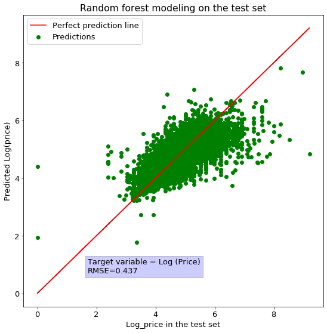

```python
plt.figure(figsize=(9,9))
plt.title("Random forest modeling on the test set")
plt.scatter(y_test,final_predictions,color='g', label='Predictions')
plt.plot(y_test,y_test,'r',label='Perfect prediction line')
#labeling
plt.xlabel("Log_price in the test set")
plt.ylabel("Predicted Log(price)")
plt.text(1.7, 0.7, 'Target variable = Log (Price)'+'\n'+'RMSE=%.3f' % final_rmse, bbox=dict(facecolor='blue', alpha=0.2))
plt.legend()
```

We can see that the model performed not as great as it did on the training set.

# 4.3. GUI tool for poential hosts and customers

```python
#defining an empty dataframe to store information
df_try=None

#using uszipcode package to get the longitude and latitude from a zipcode
from uszipcode import SearchEngine
search = SearchEngine(simple_zipcode=True) # set simple_zipcode=False to use rich info database

import tkinter as ttk
#----------------------------------------------------------------------

#deciding frame when the user is a customer or a host
def customer_change(a,b,c):
    c_selected=step_type.get()
    if c_selected=="Customer":
        lab2.grid_remove()
        lab3.grid_remove()
        rad4['state']='disabled'
        rad5['state']='disabled'
        lab6['text']="Don't put any number"
        mon_review['state']='disabled'
        tot_review.grid_remove()
        lab4.grid_remove()
        num_listing.grid_remove()
        lab5.grid_remove()
        num_days.grid_remove()

    else:
        lab2.grid(row=22,column=1)
        lab3.grid(row=21,column=1)
        rad4.grid(row=22, column=2)
        rad5.grid(row=22, column=3)
        tot_review.grid(row = 21, column = 2)
        lab4.grid(row=24,column=1)
        num_listing.grid(row = 24, column = 2)
        lab5.grid(row=25,column=1)
        num_days.grid(row = 25, column = 2)
        rad4['state']='normal'
        rad5['state']='normal'
        lab6['text']="If yes, how many?"
        mon_review['state']='normal'

def mon_review_change(a,b,c):
    r_selected_2=radio2.get()

    if r_selected_2==0:
        lab6['text']="If yes, how many?"
        mon_review['state']='normal'

    if r_selected_2==1:
        lab6['text']="Don't put any number"
        mon_review['state']='disabled'

#radiobutton changes induce the following
def on_variable_change(a,b,c): # `trace` send 3 argument to `on_variable_change`
    #r_type: radiobutton for neighbourhood_group
    r_selected=r_type.get()
    #zipcodes downloaded from : https://www.health.ny.gov/statistics/cancer/registry/appendix/neighborhoods.htm
    if r_selected==1:
        opt['menu'].delete(0, 'end')
        new_choices = (10026, 10027, 10030, 10037, 10039,10001, 10011, 10018, 10019, 10020, 10036,
                      10029, 10035,10010, 10016, 10017, 10022,10012, 10013, 10014,10004, 10005, 10006, 10007, 10038, 10280,10002, 10003, 10009,
                      10021, 10028, 10044, 10065, 10075, 10128,10023, 10024, 10025,10031, 10032, 10033, 10034, 10040)
        new_choices=sorted(new_choices)
        for choice in new_choices:
            opt['menu'].add_command(label=choice, command=ttk._setit(r_step_goal, choice))
            r_step_goal.set("SELECT")

    if r_selected==2:
        opt['menu'].delete(0, 'end')
        new_choices = (11361, 11362, 11363, 11364,11354, 11355, 11356, 11357, 11358, 11359, 11360,11365, 11366, 11367,11412, 11423, 11432, 11433, 11434, 11435, 11436,
                       11101, 11102, 11103, 11104, 11105, 11106,11374, 11375, 11379, 11385,11691, 11692, 11693, 11694, 11695, 11697,
                       11004, 11005, 11411, 11413, 11422, 11426, 11427, 11428, 11429,11414, 11415, 11416, 11417, 11418, 11419, 11420, 11421,
                       11368, 11369, 11370, 11372, 11373, 11377, 11378)
        new_choices=sorted(new_choices)
        for choice in new_choices:
            opt['menu'].add_command(label=choice, command=ttk._setit(r_step_goal, choice))
        r_step_goal.set("SELECT")

    if r_selected==3:
        opt['menu'].delete(0, 'end')
        new_choices = (10453, 10457, 10460,10458, 10467, 10468,10451, 10452, 10456,10454, 10455, 10459, 10474,
                      10463, 10471,10466, 10469, 10470, 10475,10461, 10462,10464, 10465, 10472, 10473)
        new_choices=sorted(new_choices)
        for choice in new_choices:
            opt['menu'].add_command(label=choice, command=ttk._setit(r_step_goal, choice))
        r_step_goal.set("SELECT")

    if r_selected==4:
        opt['menu'].delete(0, 'end')
        new_choices = (11212, 11213, 11216, 11233, 11238,11209, 11214, 11228,11204, 11218, 11219, 11230,11234, 11236, 11239,
                      11223, 11224, 11229, 11235,11201, 11205, 11215, 11217, 11231,11203, 11210, 11225, 11226,11207, 11208,11211, 11222,
                      11220, 11232,11206, 11221, 11237)
        new_choices=sorted(new_choices)
        for choice in new_choices:
            opt['menu'].add_command(label=choice, command=ttk._setit(r_step_goal, choice))
        r_step_goal.set("SELECT")

    if r_selected==5:
        opt['menu'].delete(0, 'end')
        new_choices = (10302, 10303, 10310,10306, 10307, 10308, 10309, 10312,10301, 10304, 10305,10314)
        new_choices=sorted(new_choices)
        for choice in new_choices:
            opt['menu'].add_command(label=choice, command=ttk._setit(r_step_goal, choice))
        r_step_goal.set("SELECT")


#----------------------------------------------------------------------

mainframe = ttk.Tk()

# customerType
step_type = ttk.StringVar() # there is the rule: variable name lowercase with _
r_type = ttk.IntVar()

ttk.Label(mainframe, text="User Type").grid(column=1, row=16)

ttk.Radiobutton(mainframe, text="Host", value="Host", variable=step_type).grid(column=2, row=16, sticky='E')
ttk.Radiobutton(mainframe, text="Customer", value="Customer", variable=step_type).grid(column=3, row=16, sticky='E')

step_type.set("Host")
# use `trace` after `set` because `on_variable_change` use `goal_label` which is not created yet.
step_type.trace("w", customer_change)


#Neighbourhood radiobutton
goal_label2 = ttk.Label(mainframe, text="Neighbourhood")
goal_label2.grid(column=1, row=17)
goal_radio=ttk.Radiobutton(mainframe, text="Manhattan", value=1, variable=r_type).grid(column=2, row=17, sticky='E')
goal_radio=ttk.Radiobutton(mainframe, text="Queens", value=2, variable=r_type).grid(column=3, row=17, sticky='E')
goal_radio=ttk.Radiobutton(mainframe, text="Bronx", value=3, variable=r_type).grid(column=4, row=17, sticky='E')
goal_radio=ttk.Radiobutton(mainframe, text="Brooklyn", value=4, variable=r_type).grid(column=5, row=17, sticky='E')
goal_radio=ttk.Radiobutton(mainframe, text="Staten Island", value=5, variable=r_type).grid(column=6, row=17, sticky='E')
r_type.set(1)
r_type.trace("w", on_variable_change)

#zip dropdown
##label
r_step_goal = ttk.IntVar()
r_goal_label = ttk.Label(mainframe, text="Zipcode")
r_goal_label.grid(column=1, row=18)

choices=['select']
opt = ttk.OptionMenu(mainframe,r_step_goal, *choices)
opt.config(width=9, font=('Helvetica', 10))
opt.grid(column=2,row=18)

# Room type radio
radio = ttk.IntVar()

ttk.Label(mainframe, text = "Choose room type :").grid(row=19,column=1)

rad1 = ttk.Radiobutton(mainframe,text='Entire home/apt', variable=radio, value=0)
rad1.grid(row=19, column=2)

rad2 = ttk.Radiobutton(mainframe,text='Private room', variable=radio, value=1)
rad2.grid(row=19, column=3)

rad3 = ttk.Radiobutton(mainframe,text='Shared room', variable=radio, value=2)
rad3.grid(row=19, column=4)

#minimum nights
ttk.Label(mainframe, text = "What are the required minimum nights?").grid(row=20,column=1)
min_night= ttk.Entry(mainframe)
min_night.grid(row = 20, column = 2)

#total reviews
lab3=ttk.Label(mainframe, text = "How many total reviews on this listing?")
lab3.grid(row=21,column=1)
tot_review= ttk.Entry(mainframe)
tot_review.grid(row = 21, column = 2)

#reviews per month : Radio first
lab2=ttk.Label(mainframe, text = "Do you know the number of reviews per month on this listing?")
lab2.grid(row=22,column=1)

#mon_review= Entry(mainframe)
#mon_review.grid(row = 23, column = 2)
radio2 = ttk.IntVar()

rad4 = ttk.Radiobutton(mainframe,text='Yes', variable=radio2, value=0)
rad4.grid(row=22, column=2)

rad5 = ttk.Radiobutton(mainframe,text='No', variable=radio2, value=1)
rad5.grid(row=22, column=3)

#if yes for monthly
lab6=ttk.Label(mainframe, text = "If yes, how many? :")
lab6.grid(row=23,column=1)
mon_review= ttk.Entry(mainframe)
mon_review.grid(row = 23, column = 2)

radio2.set(3)
radio2.trace("w", mon_review_change)

#listings per account
lab4=ttk.Label(mainframe, text = "How many listings do you have under this account?")
lab4.grid(row=24,column=1)
num_listing= ttk.Entry(mainframe)
num_listing.grid(row = 24, column = 2)

#availability 365
lab5=ttk.Label(mainframe, text = "How many days has this listing been available for booking?")
lab5.grid(row=25,column=1)
num_days= ttk.Entry(mainframe)
num_days.grid(row = 25, column = 2)

###########################################
###########################################
#defining empty global llst to store values
def storing_values(*args):
    global storage
    storage = []

#neighbourhood group value
    ng=r_type.get()
    if int(ng)==1:
        ngl="Manhattan"
    if int(ng)==2:
        ngl="Queens"
    if int(ng)==3:
        ngl="Bronx"
    if int(ng)==4:
        ngl="Brooklyn"
    if int(ng)==5:
        ngl="Staten Island"

#getting the lat and long from zip code
    zipcode=search.by_zipcode(str(r_step_goal.get()))
    zip_dict=zipcode.to_dict()
    lat=zip_dict["lat"]
    long=zip_dict["lng"]
#getting the room type
    room_type=radio.get()
    if room_type==0:
        rt='Entire home/apt'
    if room_type==1:
        rt='Private room'
    if room_type==2:
        rt="Shared room"

#getting the minimum night
    mn=min_night.get()
    if len(mn)==0:
        mn=None

#getting the total review
    tr=tot_review.get()
    if len(tr)==0:
        tr=None

#getting the monthly review count
    mr=radio2.get()
    if int(mr)==0:
        mrl=mon_review.get()
        #print(mon_review.get())
    else:
        mrl=None


#getting the number of listings per account
    nl=num_listing.get()
    if len(nl)==0:
        nl=None

#getting the number of listings per account
    nd=num_days.get()
    if len(nd)==0:
        nd=None

    storage.extend([ngl,lat,long,rt,mn,tr,mrl,nl,nd])
    #print(storage)

    #creating a dataframe from the list
    df_try = pd.DataFrame(storage).transpose()
    #chaning the column names
    df_try=df_try.rename(columns={0:"neighbourhood_group",1: "latitude", 2:"longitude",3: "room_type",4:"minimum_nights",5:"number_of_reviews",
                          6:"reviews_per_month",7:"calculated_host_listings_count",8:"availability_365"})

    X_try_prepd=full_pipeline.transform(df_try)


    #Making predictions using random forest model trained above
    tkint_predictions = forest_reg.predict(X_try_prepd)

    #getting exp of the predicted log_price value
    exp_price=np.expm1(tkint_predictions)
    exp_price=exp_price.round(decimals=2)
    exp_price=str(exp_price).lstrip('[').rstrip(']')
    ttk.messagebox.showinfo("Result", "The expected price is " + "$"+exp_price)

# --- start the engine ---
#r_step_goal.trace('w', storing_values)
ttk.Button(mainframe, text='Show prediction', command=storing_values).grid(row=26, column=2, sticky='W', pady=4)
mainframe.mainloop()
```

The final 'tkinter' code will generate a GUI that will ask for inputs and show predictions based on the inputs.